# Week 6 Notes and Work

Arin Vansomphone

2022-07-27

# Survival Analysis in R Notes

### Part 1: Introduction to Survival Analysis

Packages needed:

```r
library(tidyverse)
library(survival)
library(survminer)
library(lubridate)
```

- Survival data is time-to-event data that consists of a distinct start time and end time:
  - Time from surgery to death
  - Time from start of treatment to progression
- Censoring: occurs when a subject has not experienced the event of interest by the end of data collection
  - A subject may be censored due to loss of follow up or withdrawal from study
  - Censored subjects still provide information so must be included in analysis
- Use the `lubridate` package to format dates
- Calculating survival time code:

```r
# making dataset
date_ex <-
  tibble(
    sx_date = c("2007-06-22", "2004-02-13", "2010-10-27"),
    last_fup_date = c("2017-04-15", "2018-07-04", "2016-10-31")
  )

# formatting dates
date_ex %>%
  mutate(
    sx_date = ymd(sx_date),
    last_fup_date = ymd(last_fup_date)
  )
```

```
## # A tibble: 3 × 2
##   sx_date    last_fup_date
##   <date>     <date>
## 1 2007-06-22 2017-04-15
## 2 2004-02-13 2018-07-04
## 3 2010-10-27 2016-10-31
```

```r
# calculating survival times
date_ex %>%
  mutate(
    os_yrs =
      as.duration(sx_date %--% last_fup_date) / dyears(1)
  )
```

```
## # A tibble: 3 × 3
##   sx_date    last_fup_date os_yrs
##   <chr>      <chr>          <dbl>
## 1 2007-06-22 2017-04-15      9.82
## 2 2004-02-13 2018-07-04     14.4
## 3 2010-10-27 2016-10-31      6.01
```

- The Kaplan-Meier method is used to estimate survival times and probabilities, which is the product of the conditional probabilities up to the time

```r
Surv(lung$time, lung$status)[1:10]
```

```
##  [1]  306   455  1010+  210   883  1022+  310   361   218   166
```

```r
# estimating survival curves with the Kaplan-Meier method
f1 <- survfit(Surv(time, status) ~ 1, data = lung)
names(f1)
```

```
##  [1] "n"         "time"      "n.risk"    "n.event"   "n.censor"  "surv"
##  [7] "std.err"   "cumhaz"    "std.chaz"  "type"      "logse"     "conf.int"
## [13] "conf.type" "lower"     "upper"     "call"
```

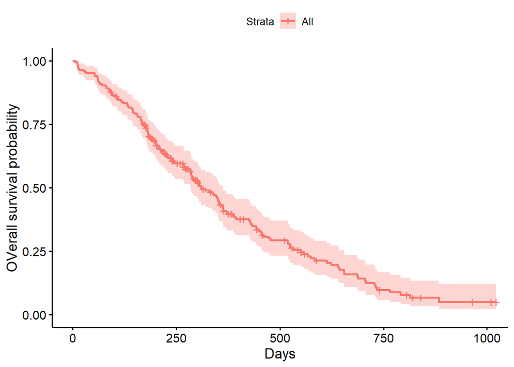

```r
# plotting curve
ggsurvplot(
  fit = survfit(Surv(time, status) ~ 1, data = lung),
  xlab = "Days",
  ylab = "OVerall survival probability"
)
```

```r
# estimating x-year survival
summary(survfit(Surv(time, status) ~ 1, data = lung), times = 365.25)
```

```
## Call: survfit(formula = Surv(time, status) ~ 1, data = lung)
##
##  time n.risk n.event survival std.err lower 95% CI upper 95% CI
##   365     65     121    0.409  0.0358        0.345        0.486
```

- Estimating median survival time: median is used because survival times are not expected to be normally distributed

```r
survfit(Surv(time, status) ~ 1, data = lung)
```

```
## Call: survfit(formula = Surv(time, status) ~ 1, data = lung)
##
##        n events median 0.95LCL 0.95UCL
## [1,] 228    165    310     285     363
```

- Always make sure to factor in censored data!
- Comparing survival times (example with sex):

```r
survdiff(Surv(time, status) ~ sex, data = lung)
```

```
## Call:
## survdiff(formula = Surv(time, status) ~ sex, data = lung)
##
##         N Observed Expected (O-E)^2/E (O-E)^2/V
## sex=1 138      112     91.6      4.55      10.3
## sex=2  90       53     73.4      5.68      10.3
##
##  Chisq= 10.3  on 1 degrees of freedom, p= 0.001
```

- The Cox regression model: semi-parametric model used to fit univariable and multivariable models with survival outcomes

```r
coxph(Surv(time, status) ~ sex, data = lung)
```

```
## Call:
## coxph(formula = Surv(time, status) ~ sex, data = lung)
##
##        coef exp(coef) se(coef)      z       p
## sex -0.5310    0.5880   0.1672 -3.176 0.00149
##
## Likelihood ratio test=10.63  on 1 df, p=0.001111
## n= 228, number of events= 165
```

- The hazard ratio represents the ratio of hazards between two groups at any particular point in time
  - HR < 1 = reduced hazard of death, HR > 1 = increased hazard of death
  - HR is the `exp(coef)`

### Part 2: Landmark Analysis and Time Dependent Covariates

These techniques calculate without being measured at the baseline * An example of this scenario is measuring at the start of treatment, not at baseline

```r
# loading the data
library(SemiCompRisks)
data(BMT, package = "SemiCompRisks")
```

- How to do landmark method:
  1. Select a fixed time after baseline as your landmark time
  2. Subset population for those followed at least until landmark time
  3. Calculated follow-up from landmark time and apply traditional tests
- Example:

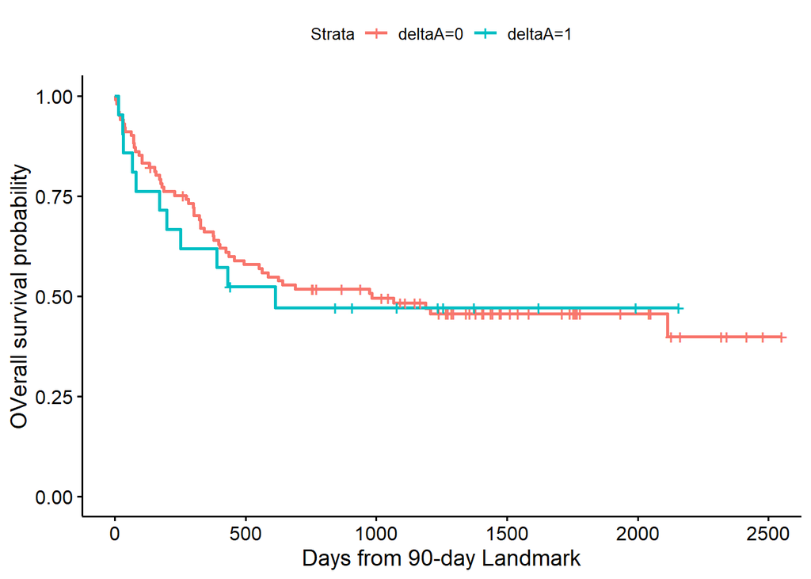

```r
# step 1: Choose 90 days
# step 2:
lm_dat <-
  BMT %>%
  filter(T1 >= 90)

# step 3:
lm_dat <- lm_dat %>%
  mutate(lm_T1 = T1 - 90
         )

ggsurvplot(
  fit = survfit(Surv(lm_T1, delta1) ~ deltaA, data = lm_dat),
  xlab = "Days from 90-day Landmark",
  ylab = "OVerall survival probability")
```

- Time-dependent covariate data setup:
  - Use when there is not an obvious landmark time or it is changing over time

### Competing Risks

Primary package for competing risks:

```r
library(cmprsk)
```

- Competing risks are when subjects have multiple possible events in a time-to-event setting
- Cumulative incidence:

```r
# data
library(MASS)
data(Melanoma, package = "MASS")

# estimating cumulative incidence
cuminc(Melanoma$time, Melanoma$status, cencode = 2)
```

```
## Estimates and Variances:
## $est
##           1000       2000       3000      4000      5000
## 1 1 0.12745714 0.23013963 0.30962017 0.3387175 0.3387175
## 1 3 0.03426709 0.05045644 0.05811143 0.1059471 0.1059471
##
## $var
##             1000         2000         3000        4000        5000
## 1 1 0.0005481186 0.0009001172 0.0013789328 0.001690760 0.001690760
## 1 3 0.0001628354 0.0002451319 0.0002998642 0.001040155 0.001040155
```

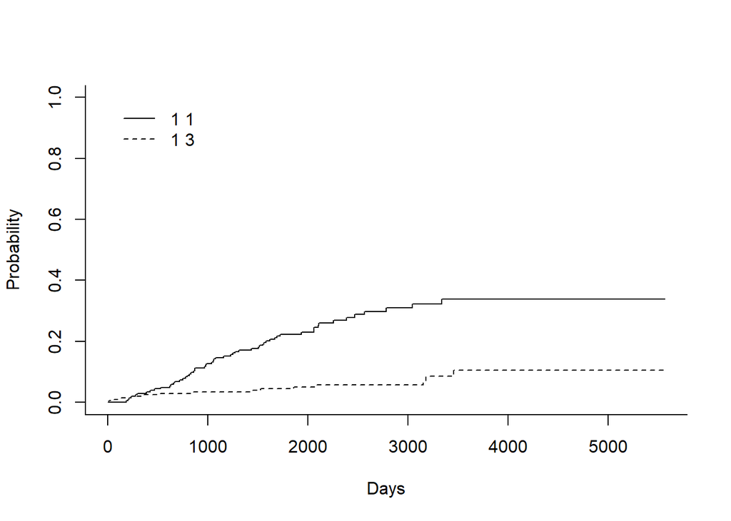

```r
# plotting the cumulative incidence
ci_fit <-
  cuminc(
    ftime = Melanoma$time,
    fstatus = Melanoma$status,
    cencode =2
  )
plot(ci_fit, xlab = "Days")
```

- Competing risks regression has two approaches:
  - Cause-specific hazards (subjects who are currently free)
  - Sub distribution hazards (subjects who have not yet experienced an event of that type)

Sub distribution example: effect of age and sex on death from melanoma, with death from other causes as a competing event

```r
shr_fit <-
  crr(
    ftime = Melanoma$time,
    fstatus = Melanoma$status,
    cov1 = Melanoma[, c("sex", "age")],
    cencode = 2
  )

shr_fit
```

```
## convergence:  TRUE
## coefficients:
##     sex     age
## 0.58840 0.01259
## standard errors:
## [1] 0.271800 0.009301
## two-sided p-values:
##  sex  age
## 0.03 0.18
```

Cause-specific hazard approach:

```r
chr_fit <-
  coxph(
    Surv(time, ifelse(status == 1, 1, 0)) ~ sex + age,
    data = Melanoma
  )

# putting data into a neat table
broom::tidy(chr_fit, exp = TRUE)
```

```
## # A tibble: 2 × 5
##   term  estimate std.error statistic p.value
##   <chr>    <dbl>     <dbl>     <dbl>   <dbl>
## 1 sex       1.82   0.268        2.24  0.0254
## 2 age       1.02   0.00866      1.91  0.0562
```

# 1,5 AG Data Exploration

### Tidying the data

```r
# loading packages
library(tidyverse)
library(readxl)

# loading the data
bloodpressure <- read_csv("bloodpressure.csv")
hba1c <- read_csv("hba1c.csv")
AG <- read_xlsx("UCLA Samples-2022-07-19 Summary.xlsx", sheet = "Summary",
                skip = 7) %>%
  rename(BSI_ID = `Sample ID`)
linkfile <- read_csv("zhou_7816_linkfile.csv")

# tidying the Batch IDs
AG <- AG %>% #linking MASKID to Batch ID
  full_join(linkfile, by = "BSI_ID") %>%
  filter(!is.na(MASKID) ) %>%
  rename(MaskID = MASKID,
         Box = `R2020 000036`)

BatchIDs <- c("R2020 000036", "R2020 000037", "R2020 000038", "R2020 000039",
             "R2020 000040", "R2020 000041", "R2020 000042", "R2020 000043")
index = c(1, which(AG$Box %in% BatchIDs), 4001)
BatchID_col = rep(BatchIDs, diff(index))
AG <- AG %>% mutate(BatchID = BatchID_col) %>%
  relocate(BatchID, .before = Box) %>%
  relocate(MaskID, .after = BSI_ID)

# replacing errors in Box
AG["Box"][AG["Box"] == "R2020 000037"] <- "Box 1"
AG["Box"][AG["Box"] == "R2020 000038"] <- "Box 1"
AG["Box"][AG["Box"] == "R2020 000039"] <- "Box 1"
AG["Box"][AG["Box"] == "R2020 000040"] <- "Box 1"
AG["Box"][AG["Box"] == "R2020 000041"] <- "Box 1"
AG["Box"][AG["Box"] == "R2020 000042"] <- "Box 1"
AG["Box"][AG["Box"] == "R2020 000043"] <- "Box 1"

# joining hba1c with the AG dataframe
AG <- AG %>%
  inner_join(hba1c, by = "MaskID")
```

### Finding the summary statistics between groups

First, I grouped by `BatchID` to see if there were major variations between batches.

```r
# putting into a table
AG %>%
  na.omit() %>%
  group_by(BatchID) %>%
  summarise(number = n(),
            mean = mean(Mean),
            median = median(Mean),
            sd = sd(Mean))
```

```
## # A tibble: 8 × 5
##   BatchID      number  mean median    sd
##   <chr>         <int> <dbl>  <dbl> <dbl>
## 1 R2020 000036   6336 16.6   13.6  16.7
## 2 R2020 000037   7433 16.8   14.2  13.6
## 3 R2020 000038   7431 10.4    9.45  6.86
## 4 R2020 000039   7518  9.06   8.4   5.54
## 5 R2020 000040   8617  9.57   8.45  6.03
## 6 R2020 000041   8422  8.83   7.95  6.75
## 7 R2020 000042   8368  9.01   8.3   5.51
## 8 R2020 000043   4885  8.94   8.25  5.92
```

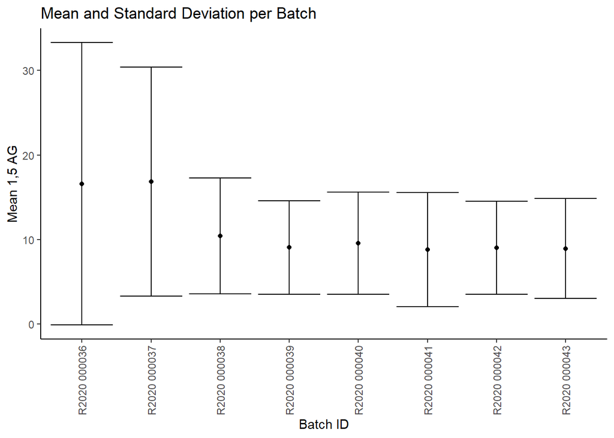

```r
# plotting data
AG %>%
  na.omit() %>%
  group_by(BatchID) %>%
  summarise(mean = mean(Mean),
            median = median(Mean),
            sd = sd(Mean)) %>%
  ggplot(aes(x = BatchID, y = mean)) +
  geom_point() +
  geom_errorbar(aes(ymin = mean - sd, ymax = mean + sd)) +
  theme_classic() +
  theme(axis.text.x = element_text(angle = 90, vjust = 0.5, hjust=1)) +
  labs(title = "Mean and Standard Deviation per Batch",
       x= "Batch ID",
       y = "Mean 1,5 AG")
```

As indicated by the graph, the first two batches have a higher mean 1,5 AG at around 16, while the other 6 batches have a mean of about 10. The six smaller batches also have a smaller standard deviation.

Now I investigate the means between each box in each batch.

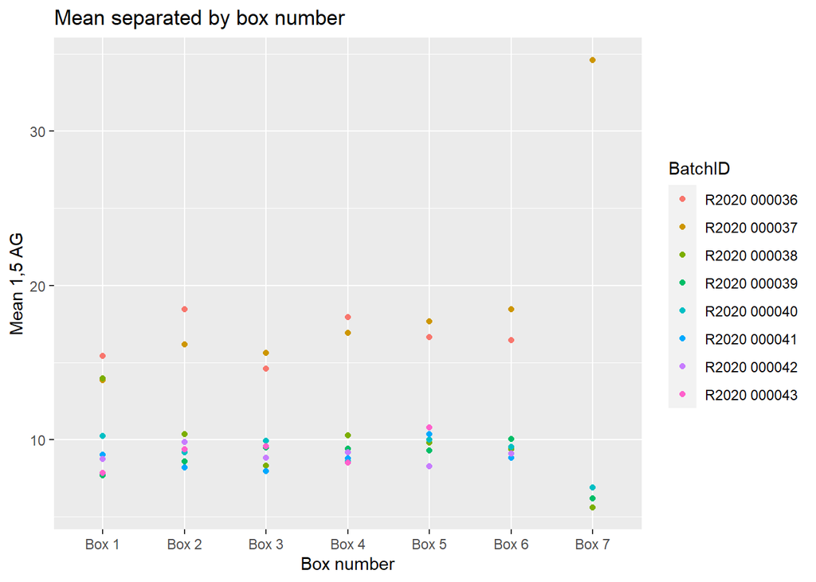

```r
AG %>%
  na.omit() %>%
  group_by(BatchID, Box) %>%
  summarise(mean = mean(Mean)) %>%
  ggplot(aes(x = Box, y = mean, color = BatchID)) +
  geom_point() +
  labs(title = "Mean separated by box number",
       x= "Box number",
       y = "Mean 1,5 AG")
```

Boxes 1-6 appear to be relatively similar to each other. However, the box 7 of each batch appears to be the outlier. Some batches do not even have a box 7!

Looking further into this we find:

```r
AG %>%
  na.omit() %>%
  filter(BatchID %in% c("R2020 000037", "R2020 000038", "R2020 000039",
                        "R2020 000040")) %>% # only batches with a box 7
  group_by(Box) %>%
  summarize(number = n())
```

```
## # A tibble: 7 × 2
##   Box   number
##   <chr>  <int>
## 1 Box 1   5257
## 2 Box 2   4831
## 3 Box 3   3538
## 4 Box 4   5609
## 5 Box 5   5303
## 6 Box 6   5919
## 7 Box 7    542
```

Box 7s have a far lower number of samples than the rest of the other boxes, which explains their large variability and outlier numbers.

One final summary statistic I calculate is the difference between reps in the data. I want to ensure that there is not much variability between reps.

```r
# creating new column
AG <- AG %>%
  mutate(`Rep Diff` = `Rep 1` - `Rep 2`)

AG %>%
  na.omit() %>%
  summarize(mean = mean(`Rep Diff`),
            median = median(`Rep Diff`),
            max = max(`Rep Diff`),
            min = min(`Rep Diff`))
```

```
## # A tibble: 1 × 4
##      mean median   max   min
##     <dbl>  <dbl> <dbl> <dbl>
## 1 -0.0461      0  2.80 -2.40
```

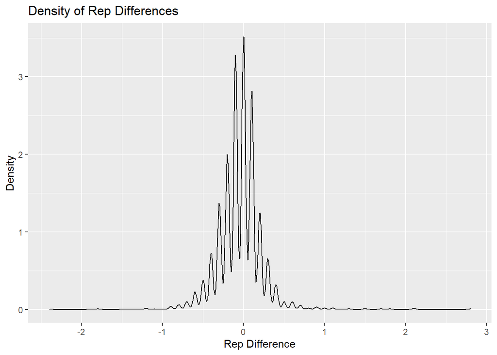

```r
# plotting onto a density plot
AG %>%
  na.omit() %>%
  ggplot(aes(x = `Rep Diff`)) +
  geom_density() +
  labs(title = "Density of Rep Differences",
       x = "Rep Difference",
       y = "Density")
```

From the graph, it looks like the `Rep Diff` is normally distributed around 0 (The reason why it is oscillating so much is because the `Rep Diff` is a discrete value, and this is a continuous x-axis). I can conclude that there is no significant difference between Reps in the data.

### Exploring the relationship between hba1c and 1,5 AG

First, I recreate the plot shown in the meeting notes. The plot gives the relationship between hba1c and 1,5 AG.

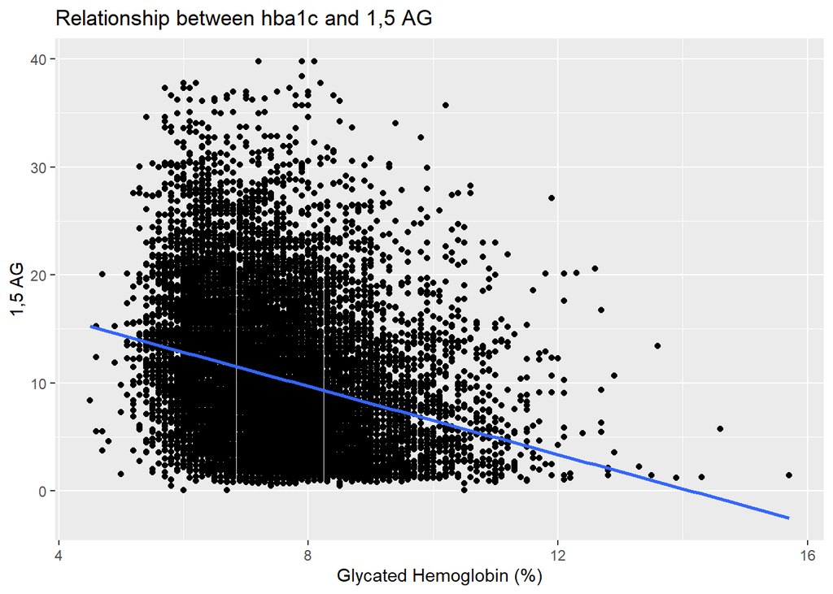

```r
AG %>%
  filter(Mean < 40, Visit %in% c("BLR", "F04", "F08", "F12")) %>%
  # this is a good place to cutoff since the sd + mean of batch 1 is around 33
  # visits are filtered to only include observations up to 12 months
  na.omit() %>%
  ggplot(aes(x = hba1c, y = Mean)) +
  geom_point() +
  geom_smooth(method = lm, se = FALSE) +
  labs(x = "Glycated Hemoglobin (%)",
       y = "1,5 AG",
       title = "Relationship between hba1c and 1,5 AG")
```

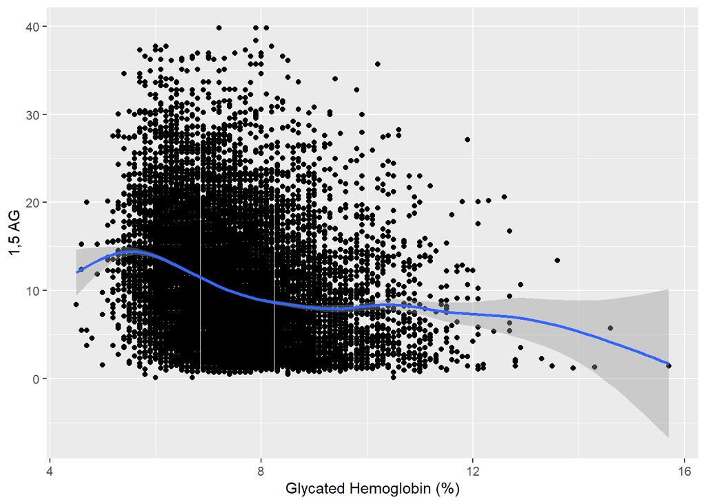

```r
# this plot with a nonlinear fit
AG %>%
  filter(Mean < 40, Visit %in% c("BLR", "F04", "F08", "F12")) %>%
  na.omit() %>%
  ggplot(aes(x = hba1c, y = Mean)) +
  geom_point() +
  geom_smooth() +
  labs(x = "Glycated Hemoglobin (%)",
       y = "1,5 AG")
```

From these graphs, there appears to be a slight negative correlation between hba1c and 1,5 AG. Ou nonlinear fitting graph tells us that the correlation is strongest at the beginning, between 6 and 8 percent of hba1c.

Let’s quantify the correlation and calculate the Pearson correlation coefficient. To do that the `ggpubr` package is required.

```r
library(ggpubr)
cor.test(AG$hba1c, AG$Mean, method = "pearson")
```

```
##
##  Pearson's product-moment correlation
##
## data:  AG$hba1c and AG$Mean
## t = -45.401, df = 59008, p-value < 2.2e-16
## alternative hypothesis: true correlation is not equal to 0
## 95 percent confidence interval:
##  -0.1915043 -0.1759121
## sample estimates:
##        cor
## -0.1837198
```

The Pearson correlation coefficient is **-0.184**.

After doing some reading, it makes sense why there is a negative correlation between the hba1c and 1,5 AG. Studies have shown that when blood glucose levels are over 180 mg/dL, 1,5 AG levels decrease. hba1c is a test for blood sugar levels, so it is expected that higher hba1c levels result in lower 1,5 AG levels.

### Investigating the relationship between 1,5 AG and hba1c at 12 months

Now I will plot the two biological variables against a time period of 12 months.

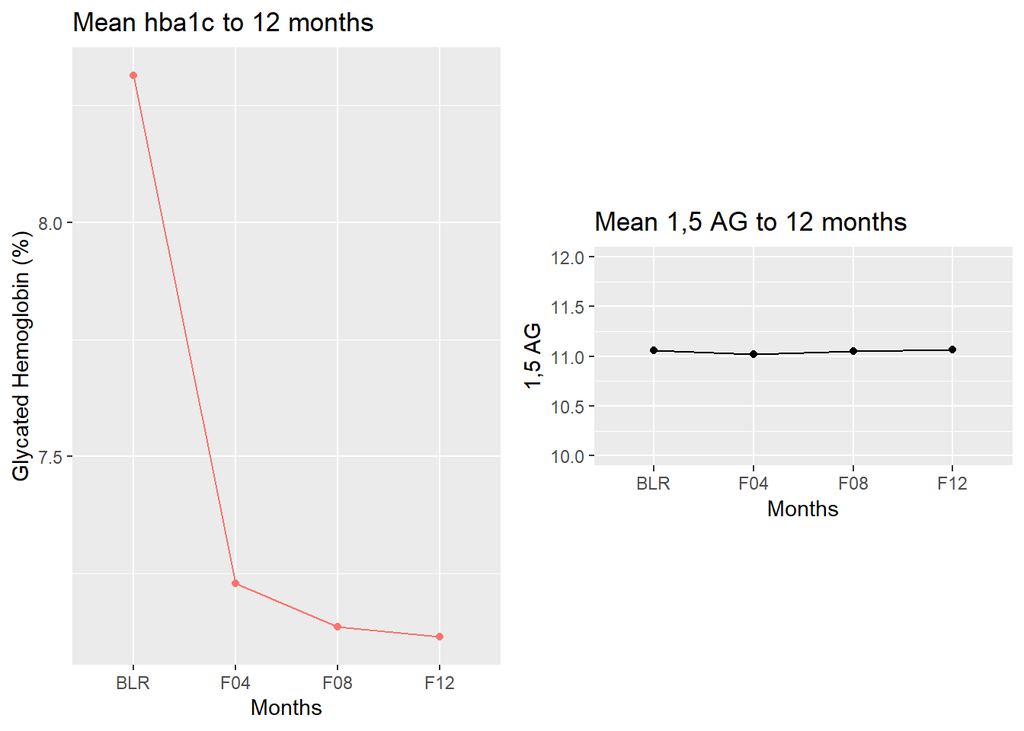

```r
# for hba1c
hbplot <- AG %>%
  filter(Visit %in% c("BLR", "F04", "F08", "F12")) %>%
  group_by(Visit) %>%
  na.omit() %>%
  summarize(meanhba1c = mean(hba1c),
            mean15ag = mean(Mean)) %>%
  ggplot(aes(x = Visit, y = meanhba1c, color = "red")) +
  geom_line(aes(group = 1)) +
  geom_point() +
  theme(legend.position = "none") +
  labs(title = "Mean hba1c to 12 months",
       x = "Months",
       y = "Glycated Hemoglobin (%)")

# for 1,5 AG
agplot <- AG %>%
  filter(Visit %in% c("BLR", "F04", "F08", "F12")) %>%
  group_by(Visit) %>%
  na.omit() %>%
  summarize(meanhba1c = mean(hba1c),
            mean15ag = mean(Mean)) %>%
  ggplot(aes(x = Visit, y = mean15ag)) +
  geom_line(aes(group = 1)) +
  scale_color_manual(values = "Blue") +
  geom_point() +
  theme(legend.position = "none") +
  labs(title = "Mean 1,5 AG to 12 months",
       x = "Months",
       y = "1,5 AG") +
  coord_fixed(ylim = c(10,12))

#combining the plots onto one window
ggarrange(hbplot, agplot, ncol = 2, nrow = 1)
```

Remarkably, there is hardly any change in 1,5 AG levels over the 12 month period, while there is a significant drop in hba1c levels. Upon doing further research, the average 1,5 AG level is about 10.7 (NCBI). I believe that since the treatments of the trial are lowering the hba1c levels, the 1,5 AG levels should remain close to normal levels. This explains why there is little change in 1,5 AG levels over the 12 month period.